# Machine-Learning-vol.06-パーセプトロン

## 6.1 分類問題とは

パーセプトロンは**脳の神経細胞であるニューロンを模した分類モデル**です｡非常に単純なモデルであるため､実際に利用されることはほとんどありません｡しかし､この後で学ぶ**ロジスティック回帰**や**SVM**あるいは**ニューラルネットワーク**などの**多くの有用なモデルの基本構造になっている**という意味で学ぶ意義があります｡構造としては､**線形分類器**といってこれまで回帰問題を解くために利用していた**線形モデル**を､分類問題に適用しています｡基本的には**2クラス分類**を行いますが､それを応用して3クラス以上の**多クラス分類**にも適用できます｡

### 分析ストーリー : 植物の種分化研究

今回のストーリーは**アカデミックな場面**を想定したものです｡植物学の研究のひとつに､**種分化研究**という**生物学的な種が誕生するまでの歴史的プロセスを解き明かそうとする領域**があります｡とある植物学者は､種分化研究の題材に**アヤメの花**を選びました｡そのルーツを知るため､まずは**アヤメの花の3つの品種について形状の違いを調査し､その結果を定量的に評価することを目指しました**｡機械学習によって**品種ごとの形状の基準がどこにあるのかを明確にします**｡

[figure not shown]

### irisデータ

irisデータとは､**3品種×50個=計150個**のアヤメ(iris)の花について**｢がく片(sepal)｣と｢花びら（petal）｣のそれぞれについて長さと幅**を記録したデータです｡これら4つの特徴量を説明変数として､**品種を表すクラスラベル**を予測します｡このデータは､米国の植物学者である**エドガー アンデルセン**の研究によって収集され､のちにイギリスの統計学者である**ロナルド･フィッシャー**との共同研究に利用されました｡

[figure not shown]

出典: [Iris flower data set](https://en.wikipedia.org/wiki/Iris_flower_data_set)

[figure not shown]

分類問題とは､**サンプルを複数あるクラスのどこに振り分けるかを考える問題**です｡統計解析の領域では､**判別分析**とも呼ばれます｡回帰と違って､**クラスラベルには連続性はありません**｡

[figure not shown]

### 6.1.1 適用例

分類問題は､**機械学習の手法の中でも特に非常に適用範囲が広いです**｡あらゆる場面で利用され､事例にも枚挙に暇がありません｡

- 送られてきたメールを､スパムメールかそうでないかを判別する
- 病院に診察に来た患者が､癌にかかっているかを判定する
- 紙に手書きで書いてある数字が､どの数字であるかを認識する
- クレジットカードの取引の不正を検知する
- インターネットサービスの顧客が解約をしそうかどうか判定する
- ECサイトに出品された商品をカテゴリ分けして､自動でタグを付ける

### 6.1.2 分類問題の目標

回帰問題の目標が**最適な回帰式を求めること**だったのに対して､分類問題の目標は**最適な決定境界を求めること**です｡決定境界とは､クラスどうしの境目となる線のことです｡回帰直線を求めることで､**説明変数がわかれば目的変数がわかる**ように､決定曲線を定めることで､**説明変数がわかれば､クラスラベルがわかる**ことを目指します｡結局は､回帰のときと同じように**最適な直線ないし曲線の方程式を求めることができればいい**ので､やることは回帰のときとそれほど大きくは変わりません｡

[figure not shown]

## 6.2 コンセプトと定式化

この節では､パーセプトロンというものがどういったものなのか､その**コンセプト**と**定式化**までの過程を紹介します｡

### 6.2.1 ニューロンの模倣

パーセプトロンは初期の人工知能研究の中で生まれた分類モデルであり､**神経細胞であるニューロンを模した構造**をしています｡ニューロンが**電気信号によって情報の処理･伝達の機能を､数値計算に置き換えています**｡

[figure not shown]

#### ニューロン

1. 外部から**電気信号**が入力される
2. 樹状突起でおこる**電圧**で入力が変化する
3. 細胞体に**電気信号が蓄積される**
4. ある一定量以上が蓄積されると発火し､**他のニューロンに電気信号を送り出す**

#### パーセプトロン

1. 外部から**説明変数**が入力される
2. エッジに格納されている**重みパラメータ**により入力が変化する
3. ノードに**線形入力 $\boldsymbol{w}^T \boldsymbol{x}$ が格納される**
4. 線形入力が一定量を超えない場合は-1を､**超えた場合は+1を出力する**

### 6.2.2 計算規則

パーセプトロンの計算は､**線形モデル**を用いて行われます｡回帰問題と同じように線形入力を計算して､**あらかじめ設定したしきい値を超えるか超えないかを判定し､超えた場合は+1のラベルを､超えなかった場合は-1のラベルを出力します**｡また､出力に変換を加える関数を**活性化関数**といい､今回利用している活性化関数は**ステップ関数（ヘビサイド関数）**と呼ばれます｡

$$u = w_0x_0 + w_1x_1 + ... + w_dx_d$$

$$ \Phi(u) =\begin{eqnarray} \left\{ \begin{array}{l} +1\ \ (u \geq 0) ･･･class 0\\ -1\ \ (u < 0)･･･class 1 \end{array} \right. \end{eqnarray} $$

[figure not shown]

### 6.2.3 誤差関数の定義

パーセプトロンの学習規則は､**これまでに扱ってきた二乗誤差関数での勾配降下法とは異なります**｡**予測と正解のクラスラベルで単純に差をとり､そこに学習率が掛け算されています**｡また､形式上説明変数 $x_j$ も掛け算しています｡

$$\Delta \boldsymbol{w_j} = \eta (y^{(i)} -\Phi(u^{(i)})) x_j^{(i)}$$

パーセプトロンの場合､**クラスラベルは±1で与えられていますので**､ $y^{(i)} -\Phi(u^{(i)})$ の部分は以下の表のように定まります｡そのため､**誤差は予測が当たっていれば0に､外れていれば±2になります**｡これをもとに､**誤分類の個数を減らそうとする修正が可能になります**｡

[figure not shown]

### 6.2.4 線形分離可能な問題

パーセプトロンは､**データが完全な線形分離が可能である**という前提を置いています｡パーセプトロンは**間違いの個数**に応じて修正を繰り返すので､**線形分離ができない問題の場合は収束しません**｡｢ああでもない､こうでもない｣と､行ったり来たりの学習を繰り返すことになり得ます｡こうした限界があることが､パーセプトロンの弱点です｡ちなみに､8章で紹介する分類モデルの**SVM**は､線形分離不可能な問題にも対応しています｡

[figure not shown]

## 6.3 データの観察

データの理解のステップとして､今回扱うirisデータの内容を観察していきます｡

### 6.3.1 データの読み込み

irisデータは､sklearn.datasetsに収録されています｡Bostonデータと同様の手順で利用できます｡

```python
# 必要ライブラリのインポート
import numpy as np
import pandas as pd
import matplotlib.pyplot as plt
%matplotlib inline
```

```python
# irisデータのロード
from sklearn.datasets import load_iris
iris = load_iris()
```

```python
# データの詳細を出力
print(iris.DESCR)
```

```
Iris Plants Database
====================

Notes
-----
Data Set Characteristics:
    :Number of Instances: 150 (50 in each of three classes)
    :Number of Attributes: 4 numeric, predictive attributes and the class
    :Attribute Information:
        - sepal length in cm
        - sepal width in cm
        - petal length in cm
        - petal width in cm
        - class:
                - Iris-Setosa
                - Iris-Versicolour
                - Iris-Virginica
    :Summary Statistics:

    ============== ==== ==== ======= ===== ====================
                    Min  Max   Mean    SD   Class Correlation
    ============== ==== ==== ======= ===== ====================
    sepal length:   4.3  7.9   5.84   0.83    0.7826
    sepal width:    2.0  4.4   3.05   0.43   -0.4194
    petal length:   1.0  6.9   3.76   1.76    0.9490  (high!)
    petal width:    0.1  2.5   1.20  0.76     0.9565  (high!)
    ============== ==== ==== ======= ===== ====================

    :Missing Attribute Values: None
    :Class Distribution: 33.3% for each of 3 classes.
    :Creator: R.A. Fisher
    :Donor: Michael Marshall (MARSHALL%PLU@io.arc.nasa.gov)
    :Date: July, 1988

This is a copy of UCI ML iris datasets.
http://archive.ics.uci.edu/ml/datasets/Iris

The famous Iris database, first used by Sir R.A Fisher

This is perhaps the best known database to be found in the
pattern recognition literature.  Fisher's paper is a classic in the field and
is referenced frequently to this day.  (See Duda & Hart, for example.)  The
data set contains 3 classes of 50 instances each, where each class refers to a
type of iris plant.  One class is linearly separable from the other 2; the
latter are NOT linearly separable from each other.

References
----------
   - Fisher,R.A. "The use of multiple measurements in taxonomic problems"
     Annual Eugenics, 7, Part II, 179-188 (1936); also in "Contributions to
     Mathematical Statistics" (John Wiley, NY, 1950).
   - Duda,R.O., & Hart,P.E. (1973) Pattern Classification and Scene Analysis.
     (Q327.D83) John Wiley & Sons.  ISBN 0-471-22361-1.  See page 218.
   - Dasarathy, B.V. (1980) "Nosing Around the Neighborhood: A New System
     Structure and Classification Rule for Recognition in Partially Exposed
     Environments".  IEEE Transactions on Pattern Analysis and Machine
     Intelligence, Vol. PAMI-2, No. 1, 67-71.
   - Gates, G.W. (1972) "The Reduced Nearest Neighbor Rule".  IEEE Transactions
     on Information Theory, May 1972, 431-433.
   - See also: 1988 MLC Proceedings, 54-64.  Cheeseman et al"s AUTOCLASS II
     conceptual clustering system finds 3 classes in the data.
   - Many, many more ...
```

```python
# 含まれている特徴量を確認
# [がく片の長さ(cm), がく片の幅(cm), 花びらの長さ(cm), 花びらの幅(cm)]
columns = iris.feature_names
columns
```

```
['sepal length (cm)',
 'sepal width (cm)',
 'petal length (cm)',
 'petal width (cm)']
```

```python
# 説明変数を確認
# [がくの長さ(cm), がくの幅(cm), 花びらの長さ(cm), 花びらの幅(cm)]
X = iris.data
X[:10]
```

```
array([[ 5.1,  3.5,  1.4,  0.2],
       [ 4.9,  3. ,  1.4,  0.2],
       [ 4.7,  3.2,  1.3,  0.2],
       [ 4.6,  3.1,  1.5,  0.2],
       [ 5. ,  3.6,  1.4,  0.2],
       [ 5.4,  3.9,  1.7,  0.4],
       [ 4.6,  3.4,  1.4,  0.3],
       [ 5. ,  3.4,  1.5,  0.2],
       [ 4.4,  2.9,  1.4,  0.2],
       [ 4.9,  3.1,  1.5,  0.1]])
```

```python
# 目的変数を確認
# 0: Setosa(50個)
# 1: Versicolour(50個)
# 2: Virginica(50個)
y = iris.target
y
```

```
array([0, 0, 0, 0, 0, 0, 0, 0, 0, 0, 0, 0, 0, 0, 0, 0, 0, 0, 0, 0, 0, 0, 0,
       0, 0, 0, 0, 0, 0, 0, 0, 0, 0, 0, 0, 0, 0, 0, 0, 0, 0, 0, 0, 0, 0, 0,
       0, 0, 0, 0, 1, 1, 1, 1, 1, 1, 1, 1, 1, 1, 1, 1, 1, 1, 1, 1, 1, 1, 1,
       1, 1, 1, 1, 1, 1, 1, 1, 1, 1, 1, 1, 1, 1, 1, 1, 1, 1, 1, 1, 1, 1, 1,
       1, 1, 1, 1, 1, 1, 1, 1, 2, 2, 2, 2, 2, 2, 2, 2, 2, 2, 2, 2, 2, 2, 2,
       2, 2, 2, 2, 2, 2, 2, 2, 2, 2, 2, 2, 2, 2, 2, 2, 2, 2, 2, 2, 2, 2, 2,
       2, 2, 2, 2, 2, 2, 2, 2, 2, 2, 2, 2])
```

### 6.3.2 データの可視化

#### 散布図行列の出力

分類問題でも散布図行列は活躍します｡ただし､観察の観点が大きく異なります｡回帰のときは､**｢説明変数と目的変数の関係性がどれだけ強いか｣**を見ました｡それに対して､分類問題のときは､**｢2つの説明変数で軸をとったとき､どれが最もきれいに分離できそうか｣**という観点で観察することが必要になります｡

```python
# DataFrame型へ変換
X_df = pd.DataFrame(X, columns=columns)
y_df = pd.DataFrame(y, columns=['speacies'])
df = pd.concat([X_df, y_df], axis=1)
df.head()
```

|  | sepal length (cm) | sepal width (cm) | petal length (cm) | petal width (cm) | speacies |
| --- | --- | --- | --- | --- | --- |
| 0 | 5.1 | 3.5 | 1.4 | 0.2 | 0 |
| 1 | 4.9 | 3.0 | 1.4 | 0.2 | 0 |
| 2 | 4.7 | 3.2 | 1.3 | 0.2 | 0 |
| 3 | 4.6 | 3.1 | 1.5 | 0.2 | 0 |
| 4 | 5.0 | 3.6 | 1.4 | 0.2 | 0 |

```python
# 基本統計量を出力
df.describe()
```

|  | sepal length (cm) | sepal width (cm) | petal length (cm) | petal width (cm) | speacies |
| --- | --- | --- | --- | --- | --- |
| count | 150.000000 | 150.000000 | 150.000000 | 150.000000 | 150.000000 |
| mean | 5.843333 | 3.054000 | 3.758667 | 1.198667 | 1.000000 |
| std | 0.828066 | 0.433594 | 1.764420 | 0.763161 | 0.819232 |
| min | 4.300000 | 2.000000 | 1.000000 | 0.100000 | 0.000000 |
| 25% | 5.100000 | 2.800000 | 1.600000 | 0.300000 | 0.000000 |
| 50% | 5.800000 | 3.000000 | 4.350000 | 1.300000 | 1.000000 |
| 75% | 6.400000 | 3.300000 | 5.100000 | 1.800000 | 2.000000 |
| max | 7.900000 | 4.400000 | 6.900000 | 2.500000 | 2.000000 |

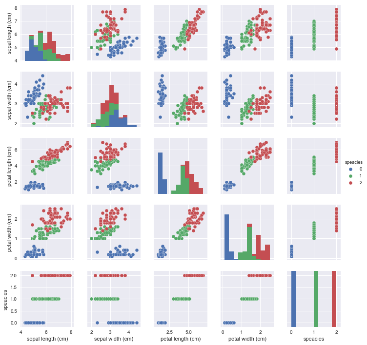

```python
# 散布図行列を出力
import seaborn as sns
sns.pairplot(df, hue='speacies', size=2.0)
plt.show()
```

irisのデータは､**がく片よりも花びらの方が品種ごとの差が現れやすいようです**｡今回は､**petal length**と**petal width**を利用して分析を行います｡

## 6.4 2クラス分類の実装

分類問題の実装を行います｡**分類モデルは基本的には2クラス分類を行いますので**､まずは2クラス分類での実装を考えます｡また､この2クラスは**完全に線形分離が可能なものにします**｡

### 6.4.1 前処理

#### 標準化

分類問題のときは､**基本的に標準化をしておいたほうが無難です**｡スケールが大きく異なっていると､スケールの小さい変数が軽視されやすくなるので､それを防いでおきます｡

```python
# データの標準化
from sklearn.preprocessing import StandardScaler
scaler = StandardScaler()
scaler.fit(X)
X_std = scaler.transform(X)
```

#### 特徴選択

```python
# 特徴選択
# setosaとversicolorの､petal lengthとpetal widthを選択
X_1 = X_std[0:100, [2, 3]]
y_1 = y[:100]
```

散布図によって､選択した2品種が完全に線形分離可能であることを確認します｡

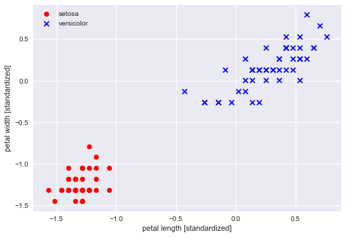

```python
# 散布図を出力
plt.scatter(X_std[:50, 2], X_std[:50,3], color="red", marker="o", label="setosa") # settosaのプロット
plt.scatter(X_std[50:100, 2], X_std[50:100, 3],color="blue", marker="x",label="versicolor") # versicolorのプロット
plt.xlabel("petal length [standardized]") # 横軸の表示を設定
plt.ylabel("petal width [standardized]")  # 縦軸の表示を設定
plt.legend(loc="upper left") # 左上に凡例を表示
plt.show()
```

#### ホールド・アウト法による分割

```python
# データセットの分割
from sklearn.model_selection import train_test_split
X_1_train, X_1_test, y_1_train, y_1_test = train_test_split(X_1, y_1, test_size=0.3, random_state=0)
```